# 3 Results

## 3.1 Energy Production and Consumption Overview

```r
invisible(library(readxl))
invisible(library(naniar))
invisible(library(ggplot2))
invisible(library(dplyr))
invisible(library(tidyr))
invisible(library(stringr))
```

```r
energy_df_annual <- read_xlsx(path='./data_source/data/energy_overview_data.xlsx', sheet=2, skip=9)
energy_df_annual <- energy_df_annual[-1, ]
energy_df_annual[, -1] <- lapply(energy_df_annual[, -1], as.numeric)
colnames(energy_df_annual)[1] <- "Year"
energy_df_annual
```

| Year | Total Fossil Fuels Production | Nuclear Electric Power Production | Total Renewable Energy Production | Total Primary Energy Production | Primary Energy Imports | Primary Energy Exports | Primary Energy Net Imports | Primary Energy Stock Change and Other | Total Fossil Fuels Consumption | Nuclear Electric Power Consumption | Total Renewable Energy Consumption | Total Primary Energy Consumption |
| --- | --- | --- | --- | --- | --- | --- | --- | --- | --- | --- | --- | --- |
| 1949 | 28.74048 | 0.000000 | 1.872627 | 30.61311 | 1.448158 | 1.591760 | -0.143602 | 0.396915 | 28.98837 | 0.000000 | 1.872627 | 30.86642 |
| 1950 | 32.55320 | 0.000000 | 1.906525 | 34.45973 | 1.912887 | 1.465322 | 0.447565 | -1.379921 | 31.61475 | 0.000000 | 1.906525 | 33.52737 |
| 1951 | 35.78212 | 0.000000 | 1.890800 | 37.67292 | 1.892425 | 2.621545 | -0.729119 | -1.057801 | 33.98774 | 0.000000 | 1.890800 | 35.88600 |
| 1952 | 34.96466 | 0.000000 | 1.848694 | 36.81336 | 2.145984 | 2.365131 | -0.219147 | -0.959659 | 33.77812 | 0.000000 | 1.848694 | 35.63455 |
| 1953 | 35.33836 | 0.000000 | 1.792616 | 37.13098 | 2.313042 | 1.866013 | 0.447029 | -0.976252 | 34.80229 | 0.000000 | 1.792616 | 36.60175 |
| 1954 | 33.75223 | 0.000000 | 1.775242 | 35.52747 | 2.347876 | 1.696301 | 0.651575 | -0.544362 | 33.85146 | 0.000000 | 1.775242 | 35.63468 |
| 1955 | 37.34680 | 0.000000 | 1.820740 | 39.16754 | 2.789908 | 2.285508 | 0.504399 | -0.456900 | 37.38042 | 0.000000 | 1.820740 | 39.21504 |
| 1956 | 39.75301 | 0.000000 | 1.843178 | 41.59619 | 3.206741 | 2.945377 | 0.261364 | -1.143199 | 38.85566 | 0.000000 | 1.843178 | 40.71435 |
| 1957 | 40.11844 | 0.000112 | 1.788598 | 41.90715 | 3.528983 | 3.439441 | 0.089541 | -1.303379 | 38.89232 | 0.000112 | 1.788598 | 40.69331 |
| 1958 | 37.20512 | 0.001915 | 1.813136 | 39.02017 | 3.884371 | 2.049839 | 1.834533 | -0.347378 | 38.68095 | 0.001915 | 1.813136 | 40.50733 |

[output cut: 65 more lines]

### 3.1.1 Primary Energy Production

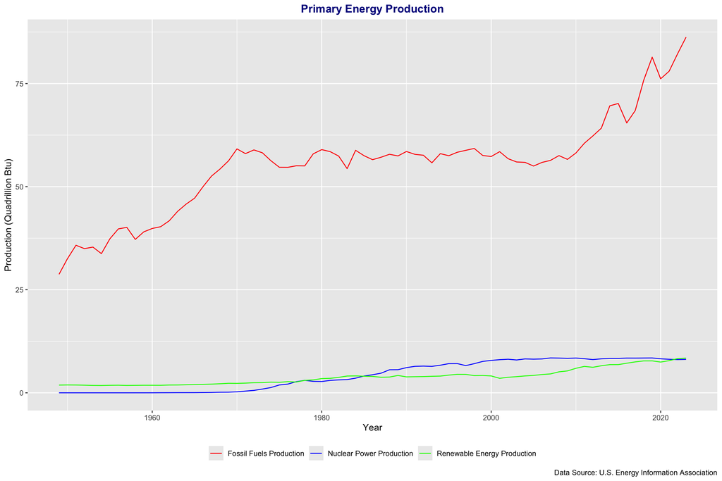

```r
ggplot(energy_df_annual, aes(x=Year)) +
  geom_line(aes(y=`Total Fossil Fuels Production`, color='Fossil Fuels Production')) +
  geom_line(aes(y=`Nuclear Electric Power Production`, color='Nuclear Power Production')) +
  geom_line(aes(y=`Total Renewable Energy Production`, color='Renewable Energy Production')) +
  labs(
    title='Primary Energy Production',
    x = 'Year',
    y = 'Production (Quadrillion Btu)',
    caption = 'Data Source: U.S. Energy Information Association',
  ) +
  theme(
    plot.title = element_text(hjust=0.5, face='bold', color='darkblue'),
    legend.position = 'bottom',
    legend.box = 'horizontal',
    legend.title = element_blank()
  ) +
  scale_color_manual(values = c('Fossil Fuels Production' = 'red',
                                'Nuclear Power Production' = 'blue',
                                'Renewable Energy Production' = 'green'))
```

The graph illustrates the trend in primary energy production from 1950 to 2020. Initially, there is a steady increase from approximately 28 quadrillion Btu in 1950 to 59 quadrillion Btu by 1970. This is followed by a plateau in production from 1970 to 2010. After 2010, there is a noticeable spike in production, which may be attributed to advancements in high-performance computing in large data centers which needs high energy.

**Fossil Fuels Production** : This line shows a significant increase over the years, indicating a substantial rise in energy production. It suggests that this energy source has been the dominant contributor to primary energy production.

**Nuclear and Renewable Energy Production** : These lines remain relatively flat compared to the fossil fuel, indicating that these energy sources have contributed less to the overall primary energy production. They show slight increases over time but are not as pronounced as the fossil fuel.